# Modeling Covid-19 at Eastern Connecticut State University

Samuel Bielaczyc - bielaczycs@my.easternct.edu

## Introduction to DCMs

In order to model Covid-19 on campus we introduce the idea of a Deterministic, Compartment Model (DCM). DCMs are frequently used to model epidemics over a continuous period of time. Deterministic means that the equations always produce the same results for a given set of parameters. A DCM does not account for variability in a disease and instead models average behavior. As displayed below, DCMs are compartmental because individuals are split into different categories and can move from one compartment to another (an individual cannot be in multiple compartments at once). One of the most basic DCMs is the SIR model which allows individuals to fall into three categories:

- $S$ - Susceptible
- $I$ - Infected
- $R$ - Recovered

A basic SIR model, taken from *Modelling infectious disease outbreaks* [3], is depicted below:

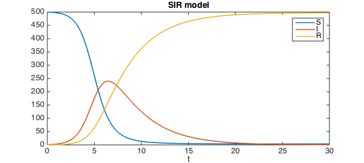

## The SEIQHFR Model

As seen above the SIR model is good for giving a basic idea about how an epidemic is behaving. However, this model only allows individuals to be classified as one of three categories (Susceptible,Infected, or Recovered), and is very simplistic. In order to effectively model Covid-19 we use the SEIQHFR model.

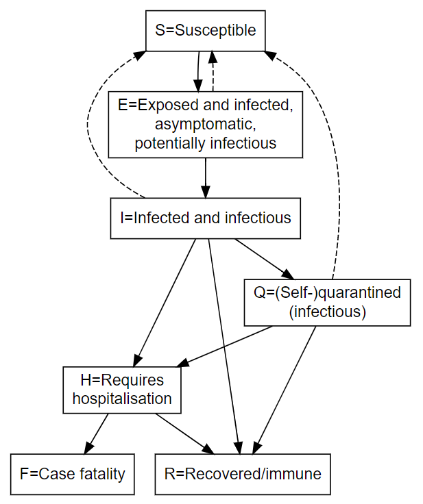

- $S$ - Susceptible
- $E$ - Exposed
- $I$ - Infectious
- $Q$ - Quarantined
- $H$ - Requires hospitalization
- $F$ - Case Fatality
- $R$ - Recovered

In the case of our model, once an individual has moved on to another compartment they cannot go back. For example, if an individual is in the *recovered* compartment they cannot go back to being *susceptible* or *infectious*; in this sense the model is unidirectional. Additionally, an individual must follow the designated path to move from one compartment to another. For example, an individual cannot be in the *susceptible* compartment and immediately jump to the *quarantined* compartment.

*Modelling the effects of public health interventions on COVID-19 transmission using R - part 2* gives a good explanation as to how a SEIQHFR model operates [4]. However, the model developed in this article uses extensions to the Epimodel package through *R* Code and does not try and develop equations to the run the model like this report.

## Model Parameters

As stated above, our model needs a defined set of parameters to model infection. These parameters are defined in the table below and are based off of Covid-19 Statistics in CT in addition to ECSU specific conditions:

Model Parameter Table

| Type | Value | Parameter | Description |
| --- | --- | --- | --- |
| Range | 1.5 (1.1 to 2.0) | $R_0$ | Number of individuals an infected person infects |
| Range | 7 (6 to 8) | $\textit{i.dur}$ | Duration in which someone is infectious |
| Fixed | 14 | $\textit{q.time}$ | Time in quarantine |
| Fixed | 0.25 | $\textit{t.prop}$ | Proportion of individuals who are tested (was q.rate) |
| Fixed | 7 | $\textit{q.freq}$ | Quarantine frequency, how often are people tested |
| Fixed | 0.0224 | $\textit{h.rate}$ | Hospitilization rate |
| Fixed | 7 | $\textit{h.dur}$ | Hospitalization duration, how long do individuals need to spend In the hospital |
| Fixed | 0.0006 | $\textit{cfr}$ | Case Fatality Rate |
| Range | 3 (2 to 4) | $\textit{e.dur}$ | Exposed duration, how long before an individual becomes infectious |

There are three parameters with ranges – $R_0$, $\textit{i.dur}$, and $\textit{e.dur}$ – and these are the parameters we will analyze first. $R_0$ is defined as the number of individuals that an infected person will infect. For example if $R_0$ is set to 2 then an infected individual will infect 2 susceptible individuals. The parameter $\textit{i.dur}$ is defined as the infected duration which is the period of time (in days) that an individual is infectious with Covid-19. Additionally, in our model $\textit{i.dur}$ works to define how long it takes $R_0$ to occur. For example, if $R_0$ is 2 and $\textit{i.dur}$ is 6 an infected person will infect 2 people over those 6 days. Finally, $\textit{e.dur}$ is the exposed duration, the period where an individual has been exposed to the disease but is not infectious. In addition to the parameters our model needs a set of initial conditions for the size of each compartment.

Initial Conditions Table

| Initial.Value | Compartment | Description |
| --- | --- | --- |
| 1595 | $S$ | The number of individuals in the susceptible compartment |
| 5 | $E$ | The number of individuals in the exposed compartment |
| 0 | $I$ | The number of individuals in the infectious compartment |
| 0 | $Q$ | The number of individuals in the quarantined compartment |
| 0 | $H$ | The number of individuals in the hospitalized compartment |
| 0 | $F$ | The number of individuals in the fatalities compartment |
| 0 | $R$ | The number of individuals in the recovered compartment |

The initial conditions defined above are based off a number of factors. The total number of individuals (1600) corresponds to an estimated 1600 students who currently live on campus at ECSU. These conditions will be used for all of our model testing and the model will be run to simulate 100 days.

## Model Equations

The number of individuals in each compartment for each time step in our model is defined by a series of differential equations that define how many individuals will be added or removed from their given compartment in addition to which individuals move to which compartment. These equations are defined as follows:

- $\begin{aligned} N= S+ E+ I+ Q+ H+ F+ R\end{aligned}$
  - $N$ is the total number of individuals in the model
- $\begin{aligned} N_\text{T}= S+ E+ I\end{aligned}$
  - $N_\text{T}$ is the total number of eligible individuals who are eligible for random testing
- $\begin{aligned} \textit{ce} = \frac{R_0}{\textit{i.dur}} \end{aligned}$
  - *ce* is the number of contacts each day per infectious individual
- $\begin{aligned} \lambda = \textit{ce} \cdot \frac{I}{N} \end{aligned}$
  - $\lambda$ is essentially the force of the infection, and is the total number of new infections each day
- $\textit{t.prop}$ is the proportion of indivdiduals who are tested. For example, for random testing of 25% of students once a week, $\textit{t.prop}$ is 0.25 if a given day of the model is a multiple of 7; or 0 otherwise.
- $\begin{aligned} \left(N_\text{T}\cdot \textit{t.prop}\cdot \frac{I}{N_\text{T}} \right)\end{aligned}$ is the number of positive tests ECSU finds on the current time step

The differential equations defined below are responsible for moving individuals between compartments.

- $\begin{aligned} dS = -\lambda S\end{aligned}$
- $\begin{aligned} dE = \left(\lambda S\right)- \left( \frac{E}{\textit{e.dur}} \right) \end{aligned}$
- $\begin{aligned} dI = \left(\frac{E}{\textit{e.dur}} \right) - \left(\frac{I}{\textit{i.dur}} \right) - \left(\textit{h.rate}\cdot I\right) - \left(N_\text{T}\cdot \textit{t.prop}\cdot \frac{I}{N_\text{T}} \right) \end{aligned}$
- $\begin{aligned} dQ = \left(N_\text{T}\cdot \textit{t.prop}\cdot \frac{I}{N_\text{T}} \right) - \left(\frac{Q}{\textit{q.dur}} \right)-(\textit{h.rate}\cdot Q) \end{aligned}$
- $\begin{aligned} dH = (\textit{h.rate}\cdot I)+(\textit{h.rate}\cdot Q) - \left(\frac{H}{\textit{h.dur}} \right) - (H\cdot \textit{cfr}) \end{aligned}$
- $\begin{aligned} dF = H\cdot\textit{cfr} \end{aligned}$
- $\begin{aligned} dR = \left(\frac{I}{\textit{i.dur}} \right) + \left(\frac{Q}{\textit{q.dur}} \right) + \left(\frac{H}{\textit{h.dur}} \right) - (H\cdot \textit{cfr}) \end{aligned}$

The article *Basic DCMs in Epimodel* [1] and *New DCMs with Epimodel* [2] give good explanations on how DCMs are built and how they function. Note that both $\lambda$ and *ce* are defined from the equations given in *New DCMs with Epimodel* [2].

## Model Example

Below is sample output from an SEIQHFR model. This model does not use the parameter values indicated above; but itprovides a good example that displays the values of each of its compartments over time.

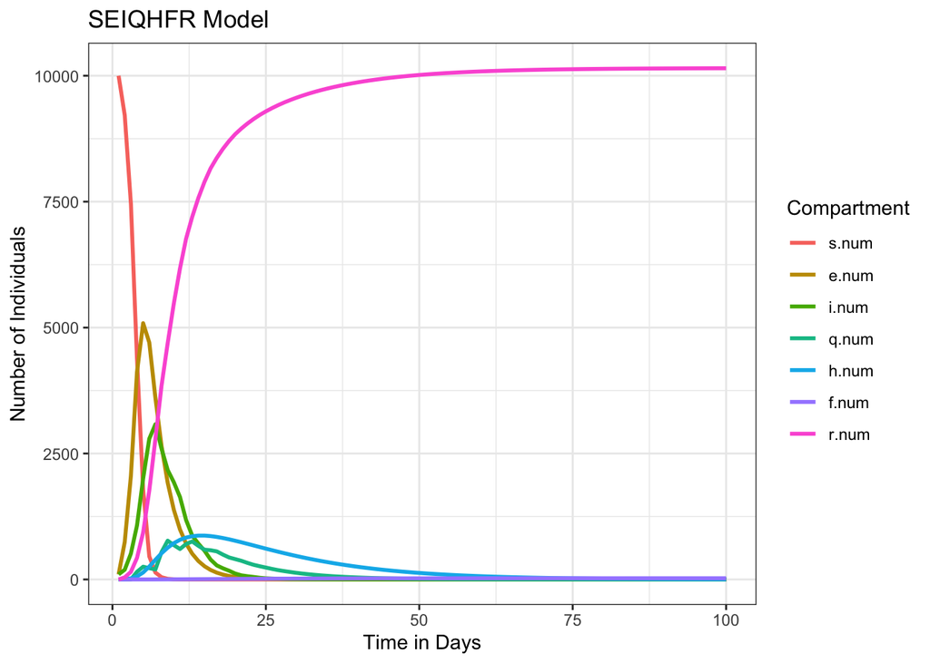

## ECSU Model

Using the parameters above with $R_0= 1.5$, $\textit{i.dur}= 7$, and $\textit{e.dur}= 3$, we get the following output:

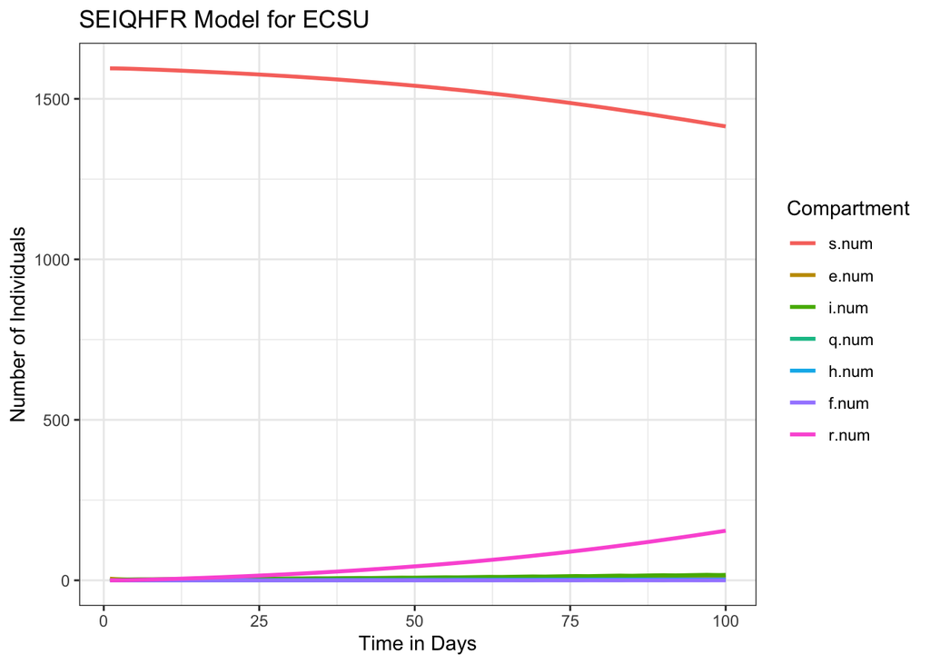

Using our defined parameters it is difficult to get a good idea as to how all the compartments change throughout the duration of the model. We will analyze this model in more detail throughout this report.

## SEIQHFR with varying $R_0$

We will first test how different $R_0$ values impact the *total* number of infected individuals (the total number of infections).

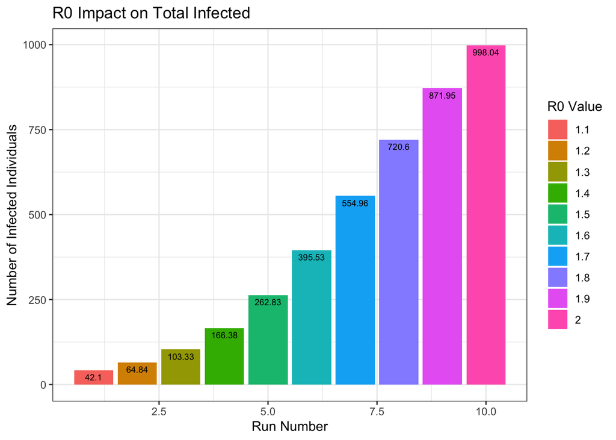

Note that in the above graph the total number of infected individuals is calculated by taking the sum of $I, R, Q, H$, and $F$ on the last “day” of the simulation (day 100). The reasoning for this is because if an individual was or is currently infected, then they will be in one of these compartments. When analyzing the above graph we see that it gives fairly predictable results. As $R_0$ increases the number of total infected individuals increases.

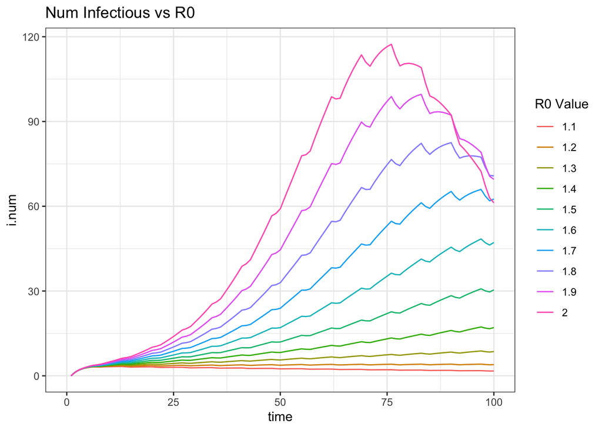

The above graph depicts how the $I$ compartment changes over the 100 simulated days. The repeated drop of infected individuals every 7 days is due to the testing that occurs which removes individuals who test positive from this compartment. Notice that as $R_0$ increases the $I$ compartment peaks earlier in the simulation. This indicates that as $R_0$ increases, not only does the number of infected individuals increase but the disease will reach its peak infection sooner.

## SEIQHFR with varying $\textit{i.dur}$

The $\textit{i.dur}$ parameter corresopnds to how long an individual will remain infectious. We want to examine how varying this parameter will effect the total number of infected individuals.

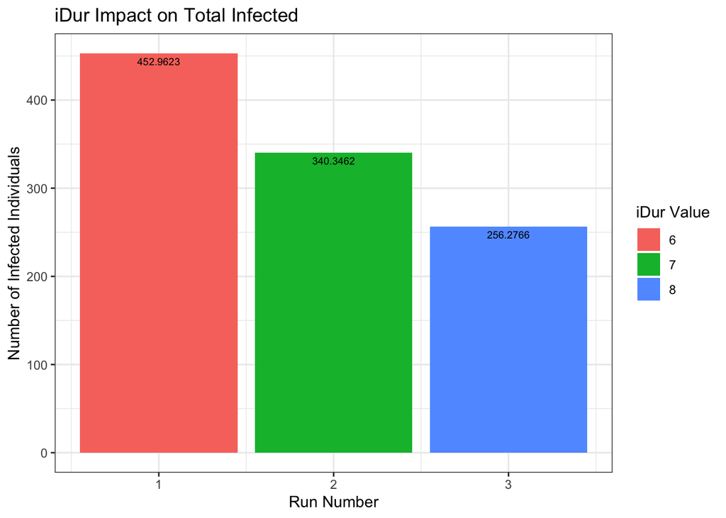

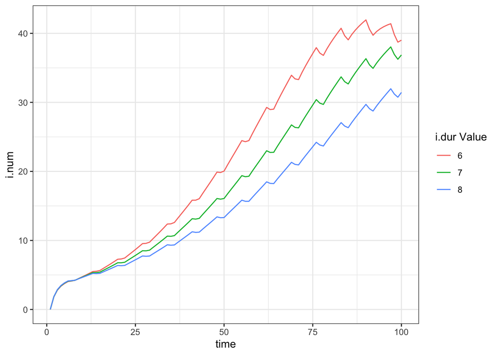

## SEIQHFR with varying $\textit{e.dur}$

In our model $\textit{e.dur}$ corresponds to how long an individual is in an exposed state after coming into contact with the disease. While exposed an individual is not immediately infectious but will become infectious based on the exposed duration ($\textit{e.dur}$).

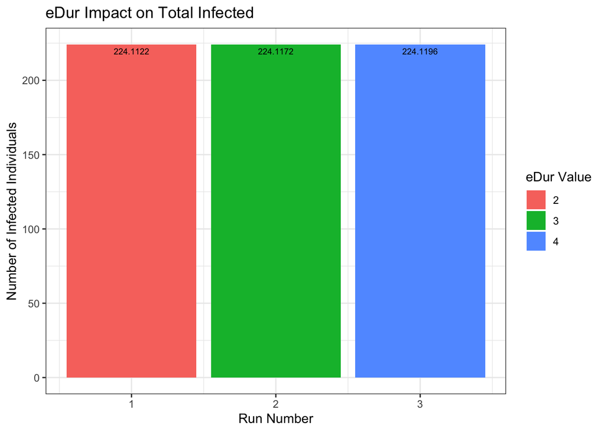

After running our model using different values for $\textit{e.dur}$ (2,3, and 4), there does not appear to be a notable difference between the total number of infected individuals. For the remainder of testing our model, we will therefore set $\textit{e.dur}$ to 3.

## SEIQHFR model with varying $R_0$ and $\textit{i.dur}$

Having established that $\textit{e.dur}$ does not seem to have any impact on the total number of infections, we will look at the effect of $R_0$ and $\textit{i.dur}$ by running simulations using all possible combinations of these parameters.

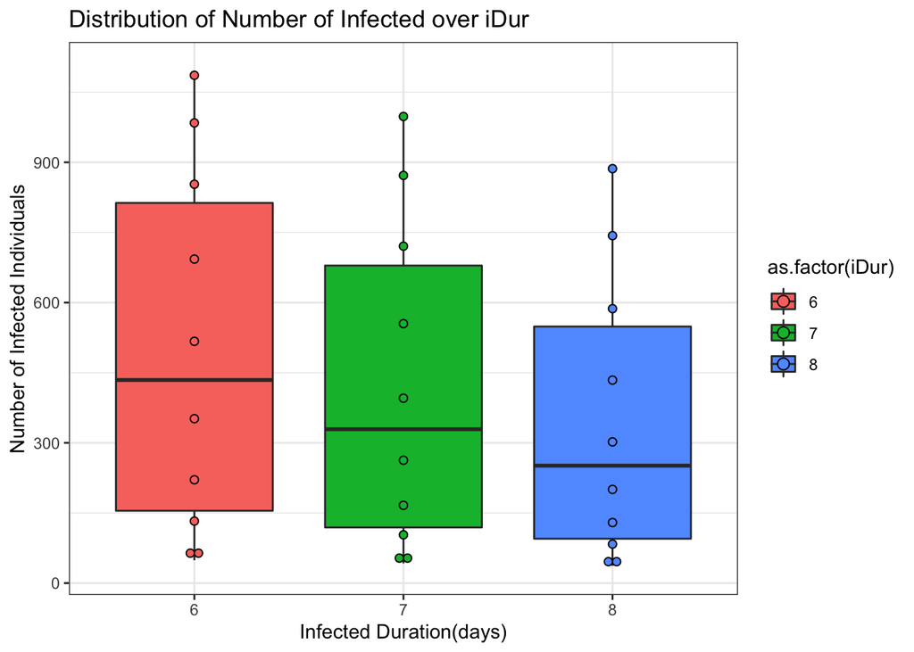

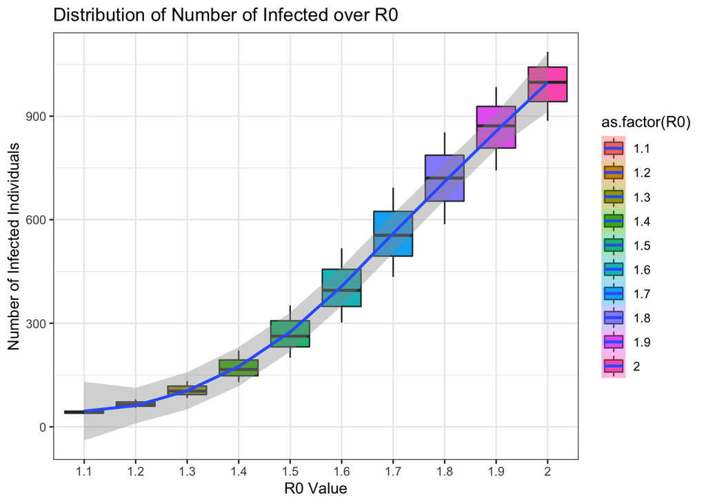

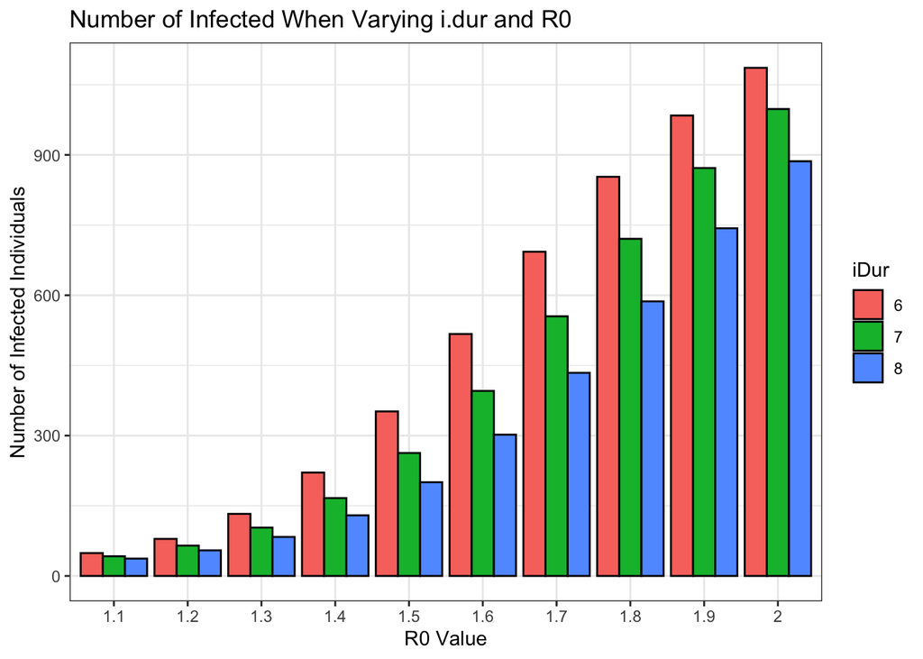

Let us first discuss the two graphs *Distribution of Number of Infected over iDur* and *Distribution of Number of Infected over $R_0$*. The first graph reflects what we have previously seen in regards to $\textit{i.dur}$ which is that as the $\textit{i.dur}$ value increases, the total number of infected individuals appears to decrease. The second graph provides more interesting information. Notice that as $R_0$ increases the total number of infected individuals increases, which is to be expected. However, note that this increase is not linear. It would appear that as $R_0$ increases there is a greater difference in the total number of infected individuals. For example an $R_0$ value of 2 as compared to 1.9 has a greater difference in the total number of infected individuals than $R_0$ of 1.1 and 1.2.

## How does varying the number of individuals being tested effect the model

The most effective way to halt a pandemic in theory would be for every individual to quarantine. However, for ECSU and in general, this is not realistic. A preventative measure taken by ECSU (and other colleges) is random testing. Currently ECSU tests 25% of its residential students every 7 days (actually, athletes and housing directors are tested more frequently, but this was not considered). The goal of the following comparison is to determine if there is a more optimal way to test students and to determine if different testing strategies can better prevent the spread of the disease. In the following tests $R_0$ is set to 1.5, $\textit{i.dur}$ is set to 7, and $\textit{e.dur}$ is set to 3.

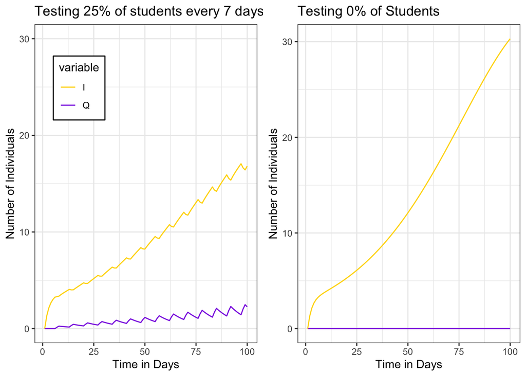

The above two graphs display the differences in $I$ and $Q$ by testing 25% of students every 7 days compared to testing 0% of students. Based on the graphs it would appear that ECSUs testing is succeeding in preventing infections. With ECSU’s current strategy the maximum number of infected individuals at a given time is roughly 18 which is seen at day 100. Additionally, we see a drop in the number of infected individuals every 7 days as individuals who test positive are placed into quarantine. Based on the second graph if ECSU were to not test anyone we see that the number of infected individuals increases over 100 days without dropping each week. It appears that without testing the model will reach a maximum of 30 individuals at a given day. We will go over more specific infection numbers later on in this report to better compare both graphs. Let us first examine if there appears to be a difference in the total number of infected individuals if we split up the 25% over the week.

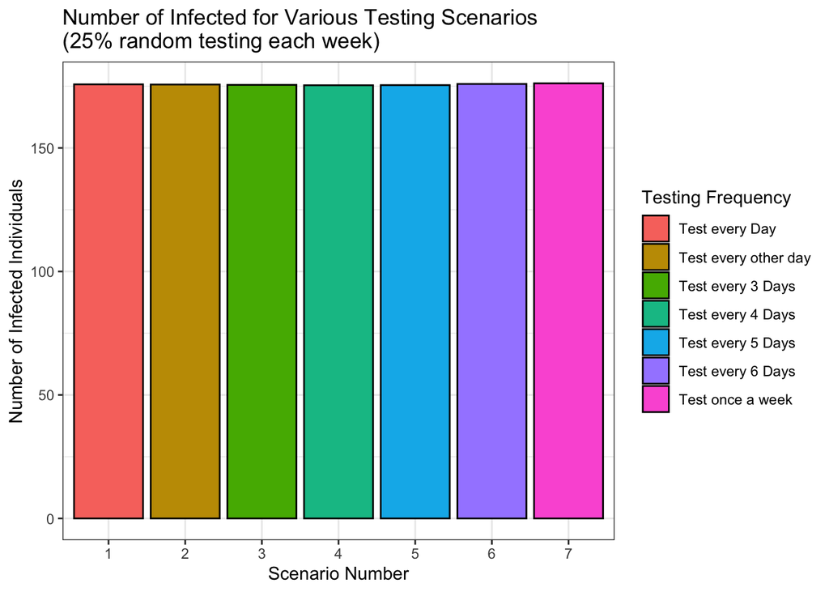

Notice that there does not appear to be any difference if we split up the testing percentage over the week. Note that in this test 25% of individuals are tested every week but the frequency of testing is divided throughout the week. It would appear that there is no difference in the total number of infections which is good for ECSU. Having to test only once a week as opposed to testing every day lowers the number of individuals needed to administer the tests because we won’t need someone on campus to test every day. Next we will experiment with other testing scenarios in order to determine if there is a more optimal testing strategy.

## Other Testing Options

We will compare additional testing scenarios with various testing percentages and frequencies to determine which is best. ECSU currently tests 25% of its students every 7 days but is there a better option? Let us compare this to the following testing setups:

- 5% of students every day
- 10% of students every 2 days
- 20% of students every 4 days
- 30% of students every 6 days
- 40% of students every 8 days
- 50% of students every 10 days

Note that there are other factors that need to be taken into account when it comes to testing. The above options are just some examples to look at how the total number of infections changes with different testing frequencies and percentages, and does not take into account staffing or other resources. Because of this the new options presented may not be practical for ECSU.

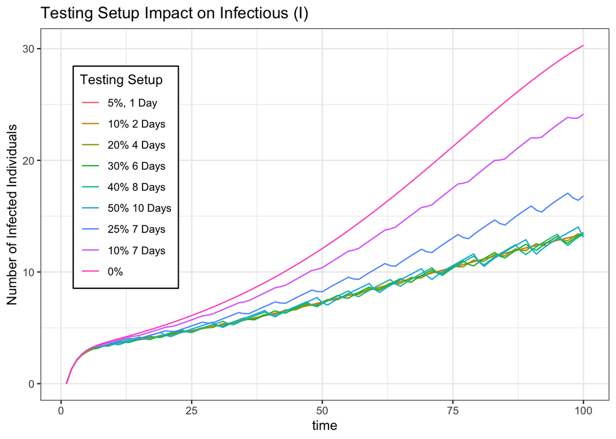

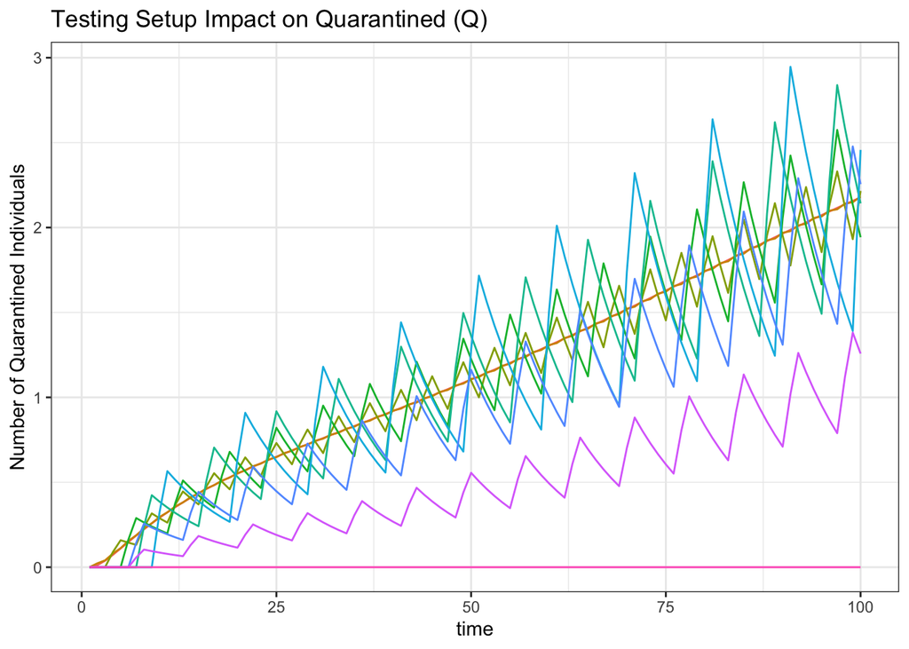

We are more interested in examining how the total number of infections changes for each run.

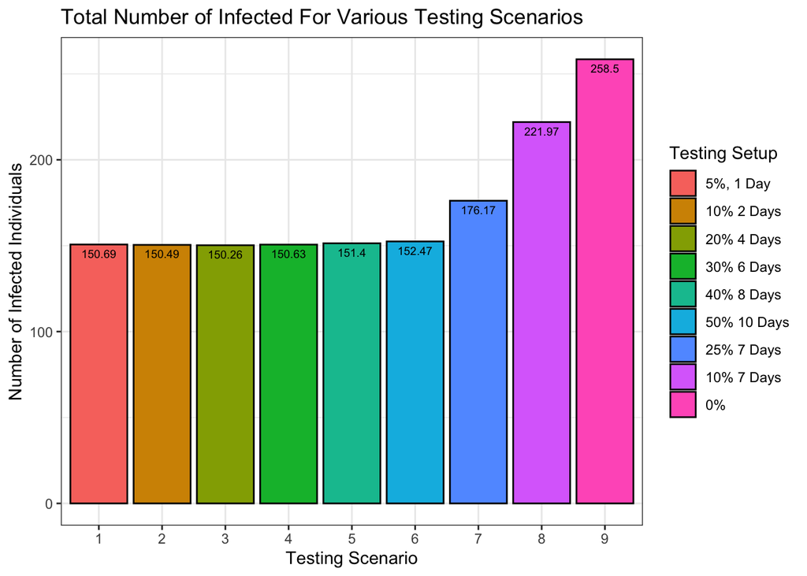

The above graph gives a good indication as to how ECSU can improve their testing. Note that ECSU is already theoretically preventing almost 80 infections with their current testing. However, this can be improved. Any of the provided solutions seem to prevent almost the same number of infections and all prevent roughly 25 more infections than what ECSU is currently doing. Note that ECSU used to test 10% of their students every 7 days. Our model indicates that ECSU’s testing strategy works much better. Based on our parameters ECSU is theoretically preventing roughly 82 infections through random testing.

## Conclusion

In this report we presented a SEIQHFR model in order to model Covid-19 at ECSU. From our testing, we conclude that $R_0$ is the most important parameter when it comes to the total number of infections. Additionally, ECSU’s current strategy of testing 25% of students every week prevents a large number of infections when compared to previous testing strategies (or compared to a scenario with no random testing). It is important to note that the model results are an estimate and do not represent actual infection numbers. Our model is reliant on defined parameters and at this point in time we can only give an educated guess as to what these values might be. Our model is also a closed system and does not model infections that might spread among commuters or faculty. Further testing on Covid-19 can help to better define parameters in order to give more accurate results. While this model was used to test Covid-19 it can be applied to any disease as long as the appropriate parameters and equations are defined. Finally, this model was a first iteration and further testing will likely allow us to produce a more advanced and improved model.

## Comments

The SEIQHFR model developed in this report was built using the R programming language and primarily uses the Epimodel package to run the model. The source code and files used in this report can be found on my github page locate at https://github.com/SBielaczyc/Modeling-Covid-19-at-ECSU

Special thanks to Dr. Dancik for all the help working on the model this semester!

## References

[1] *Basic DCMs with EpiModel*. (2015). Statnet.org, http://statnet.org/tut/BasicDCMs.html  
[2] *New DCMs with EpiModel* (2015). Statnet.org, http://statnet.org/tut/NewDCMs.html  
[3] *Modelling infectious disease outbreaks* (2014). Chebfun.org, https://www.chebfun.org/examples/ode-nonlin/ModellingDiseases.html  
[4] Churches, T. (2020, March 18). *Tim Churches Health Data Science Blog*, “Modelling the effects of public health interventions on COVID-19 transmission using R - part 2”. Tim Churches Health Data Science Blog.  
https://timchurches.github.io/blog/posts/2020-03-18-modelling-the-effects-of-public-health-interventions-on-covid-19-transmission-part-2/.